# comparison of legislative texts

Nadia Napolano

2024-03-24

The objective of this analysis is to compare the constitutional texts or texts establishing the fundamental rights of the citizen of 4 countries and the European Union.

The hypothesis on which this study is based is that traces of each country’s culture and history can be found in the main legislative texts of each country. We begin by obtaining the data through data harvesting strategies.

```r
library(rvest) # to get the data
library(tidytext) # to order the text
library(textdata)
library(ggplot2) #to visualize information
library(dplyr) #to manage dataframe
library(forcats) # to vizualize data
library(ggraph)#to optain graphs of networks
library(RColorBrewer)#data visualization
```

The Constitution of Spain

```r
library(rvest)
url <- "https://www.senado.es/web/conocersenado/normas/constitucion/detalleconstitucioncompleta/index.html?lang=en"
spagna_text <- url |>
  read_html() |>
  html_nodes(xpath = '//p[@class="p_top"]') |>
  html_text()
```

The Declaration of independence, USA

```r
url <- "https://portal.ct.gov/SOTS/Register-Manual/Section-I/Declaration-of-Independence-US-Constitution#:~:text=We%2C%20therefore%2C%20the%20Representatives%20of,that%20these%20United%20Colonies%20are%2C"

USA_text <- url %>%
  read_html() %>%
  html_nodes(xpath = '//p[font[@color="#000000"]]') %>%
  html_text()
```

The Constitution of South Africa

```r
url <- "https://www.westerncape.gov.za/legislation/bill-rights-chapter-2-constitution-republic-south-africa"
southafrica_text <- url |>
  read_html() |>
  html_nodes(xpath = '//td[@valign="top"]') |>
  html_text()
```

Charter of Fundamental Rights of the European Union

```r
library(rvest)
url <- "https://eur-lex.europa.eu/legal-content/EN/TXT/HTML/?uri=CELEX:12012P/TXT"

page <- read_html(url)
ue_text<- url |>
  read_html() |>
  html_nodes(xpath = '//p[@class="normal"]') |>
  html_text()
```

Italy, The constitution of 1948

```r
url <- "https://www.refworld.org/legal/legislation/natlegbod/1947/en/13703"
page <- read_html(url)
testo_it <- page |>
  html_nodes("p") |>
  html_text()
testo_it<- gsub("\\d+", "", testo_it)

testo_it <- gsub("This is not a UNHCR publication. UNHCR is not responsible for, nor does it necessarily endorse, its content. Any views expressed are solely those of the author or publisher and do not necessarily reflect those of UNHCR, the United Nations or its Member States.", "", testo_it)

testo_it <- gsub("\\(\\)", "", testo_it)

testo_it <- gsub("Search", "", testo_it)
```

## text cleaning

Italy

```r
library(dplyr)
library(tidytext)
testoit_df <- tibble(line = 1:383, text = testo_it)
testoit_df<- testoit_df |>
  unnest_tokens(word, text)
testoit_df <- testoit_df |>
  anti_join(stop_words, by = "word")
```

EU

```r
ue_text <- gsub("PREAMBLE", "", ue_text)
ue_text <- gsub("\\d+", "", ue_text )
ue_text <- gsub("TITLE", "", ue_text )
ue_text <- gsub("I", "", ue_text )
ue_text <- gsub("II", "", ue_text )
ue_text <- gsub("V", "", ue_text )
testoue_df <- tibble(line = 1:length(ue_text), text = ue_text)

testoue_df<- testoue_df |>
  unnest_tokens(word, text)
testoue_df <- testoue_df |>
  anti_join(stop_words, by = "word")
```

South africa

```r
southafrica_text <- gsub("\u00E2", "", southafrica_text)
southafrica_text <- gsub("\\d+", "", southafrica_text)
southafrica_text <- gsub("i ", "", southafrica_text)
southafrica_text <- gsub("ii", "", southafrica_text)
southafrica_text <- gsub("b ", "", southafrica_text)


testoSA_df <- tibble(line = 1:length(southafrica_text), text = southafrica_text)

testoSA_df <- testoSA_df |>
  unnest_tokens(word, text)

testoSA_df <- testoSA_df |>
  anti_join(stop_words, by = "word")
testoSA_df <- testoSA_df |>
  filter(nchar(word) > 1)
# the letter "â" was really difficult to take away from the dataset
testoSA_df <- testoSA_df %>%
  filter(!grepl("â", word))
```

USA

```r
USA_text <- gsub("\\d+", "", USA_text)
USA_text <- gsub("i ", "", USA_text)
USA_text <- gsub("ii", "", USA_text)
USA_text <- gsub("b ", "", USA_text)


testoUSA_df <- tibble(line = 1:length(USA_text), text = USA_text)


testoUSA_df <- testoUSA_df |>
  unnest_tokens(word, text)

testoUSA_df <- testoUSA_df |>
  anti_join(stop_words, by = "word")
testoUSA_df <- testoUSA_df |>
  filter(nchar(word) > 1)
```

SPAIN

```r
spagna_text <- gsub("\\d+", "", spagna_text)
spagna_text <- gsub("i ", "", spagna_text)
spagna_text <- gsub("ii", "", spagna_text)
spagna_text <- gsub("don", "", spagna_text)


testoes_df <- tibble(line = 1:length(spagna_text), text = spagna_text)


testoes_df <- testoes_df |>
  unnest_tokens(word, text)


testoes_df <- testoes_df |>
  anti_join(stop_words, by = "word")
testoUSA_df <- testoUSA_df |>
  filter(nchar(word) > 1)
```

## words distribution

Let’s observe the distribution of the words

Italy

```r
it_words <- testoit_df |>
  count( word, sort = TRUE)

total_words_it <- it_words |>
  summarize(total = sum(n))

total_words_it
```

```
## # A tibble: 1 × 1
##   total
##   <int>
## 1  3955
```

```r
it_words <- it_words |>
  mutate(term_frequency = n/3955)

it_words
```

```
## # A tibble: 1,251 × 3
##    word           n term_frequency
##    <chr>      <int>          <dbl>
##  1 law          133        0.0336
##  2 republic      66        0.0167
##  3 regional      53        0.0134
##  4 president     50        0.0126
##  5 council       45        0.0114
##  6 public        45        0.0114
##  7 laws          39        0.00986
##  8 chamber       34        0.00860
##  9 chambers      31        0.00784
## 10 parliament    31        0.00784
## # ℹ 1,241 more rows
```

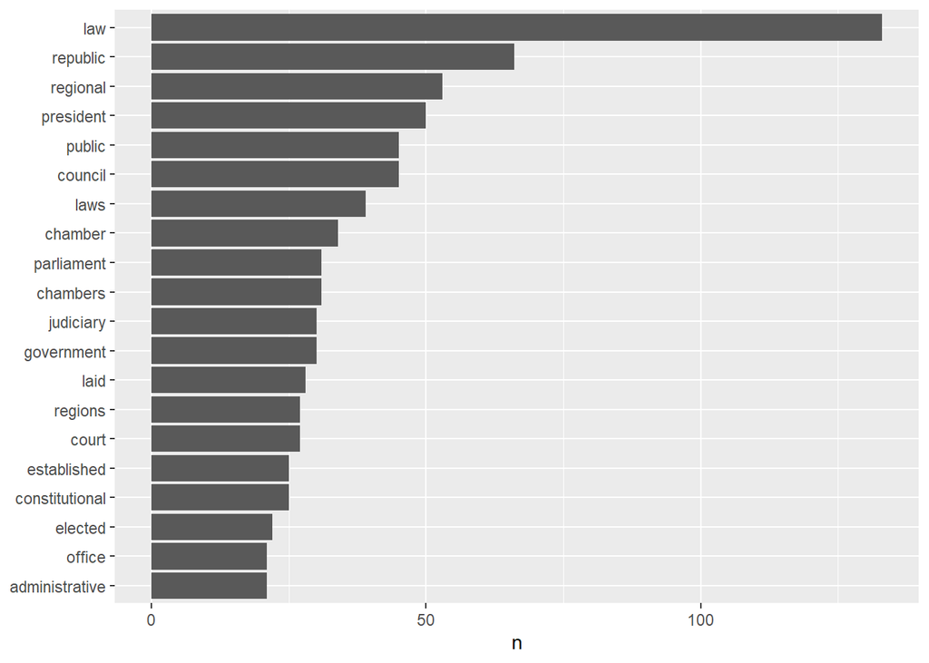

```r
library(ggplot2)

testoit_df |>
  count(word, sort = TRUE) |>
  filter(n > 20) |>
  mutate(word = reorder(word, n)) |>
  ggplot(aes(n, word)) +
  geom_col() +
  labs(y = NULL)
```

These words do not surprise me; the Italian Constitution, written in 1948, is divided into two parts: the first is about the principles of the state and the rights and duties of the citizen, while the second explains concretely how the republic functions. Therefore, I will try to filter the first 54 articles to get the initial part, which in my opinion can give excellent insights. The last word is progressivity of the first part, line 135.

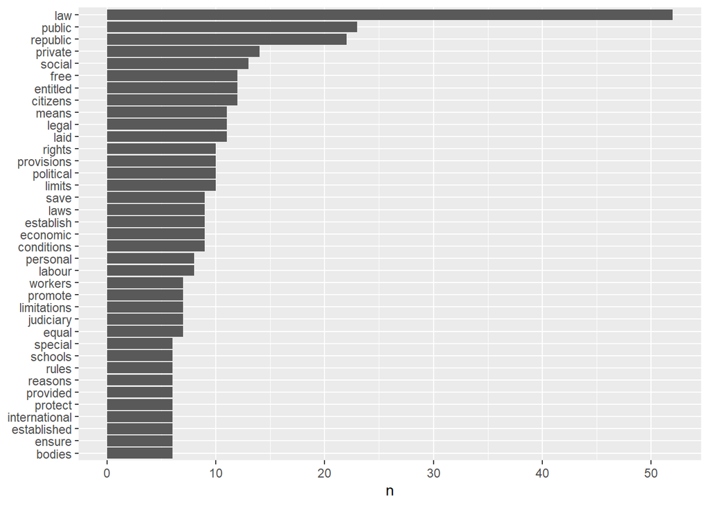

```r
testoit_df_principles <- testoit_df |>
  filter(line <= 135)
testoit_df_principles |>
  count(word, sort = TRUE) |>
  filter(n > 5) |>
  mutate(word = reorder(word, n)) |>

  ggplot(aes(n, word)) +
  geom_col() +
  labs(y = NULL)
```

In the text we find words that refer to the socialist party such as: labor and workers. This is not surprising since the constitution was written after the fascist dictatorship and after World War II, this also explains the words equal and free. I was expecting words like peace, war or women which are not mentioned as often instead. I am very curious to see the analysis of Spain, a European country that wrote the constitution in 1972 after the end of the Franco dictatorship.

Spain

```r
es_words <- testoes_df |>
  count( word, sort = TRUE)
es_words
```

```
## # A tibble: 1,864 × 2
##    word             n
##    <chr>        <int>
##  1 law            127
##  2 public         103
##  3 section         97
##  4 autonomous      87
##  5 government      79
##  6 senate          78
##  7 standing        70
##  8 congress        67
##  9 constitution    62
## 10 act             61
## # ℹ 1,854 more rows
```

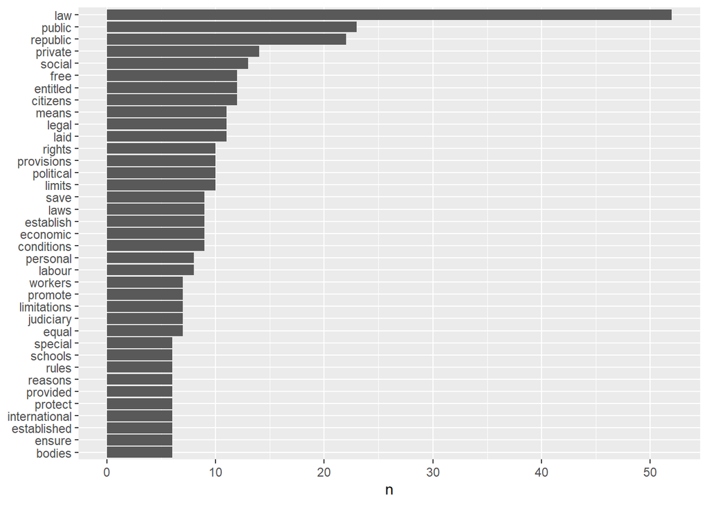

```r
testoes_df_principles <- testoes_df |>
  filter(line <= 186)

testoit_df_principles |>
  count(word, sort = TRUE) |>
  filter(n > 5) |>
  mutate(word = reorder(word, n)) |>

  ggplot(aes(n, word)) +
  geom_col() +
  labs(y = NULL)
```

South Africa I chose this country because I was very curious to see what kind of differences there might be between very distinct countries with very different backgrounds and histories. The Constitution of South Africa (Constitution of South Africa), formulates the law of the state of South Africa. It provides the legal basis for the existence of the republic, establishes the human rights and duties of citizens, and defines the structure of government.

The current constitution, the country’s fifth, was drafted by South Africa’s parliament elected in 1994 at a general election, the first with universal suffrage and without racial discrimination. It was promulgated by President Nelson Mandela on December 18, 1996, and actually came into effect on February 4, 1997.

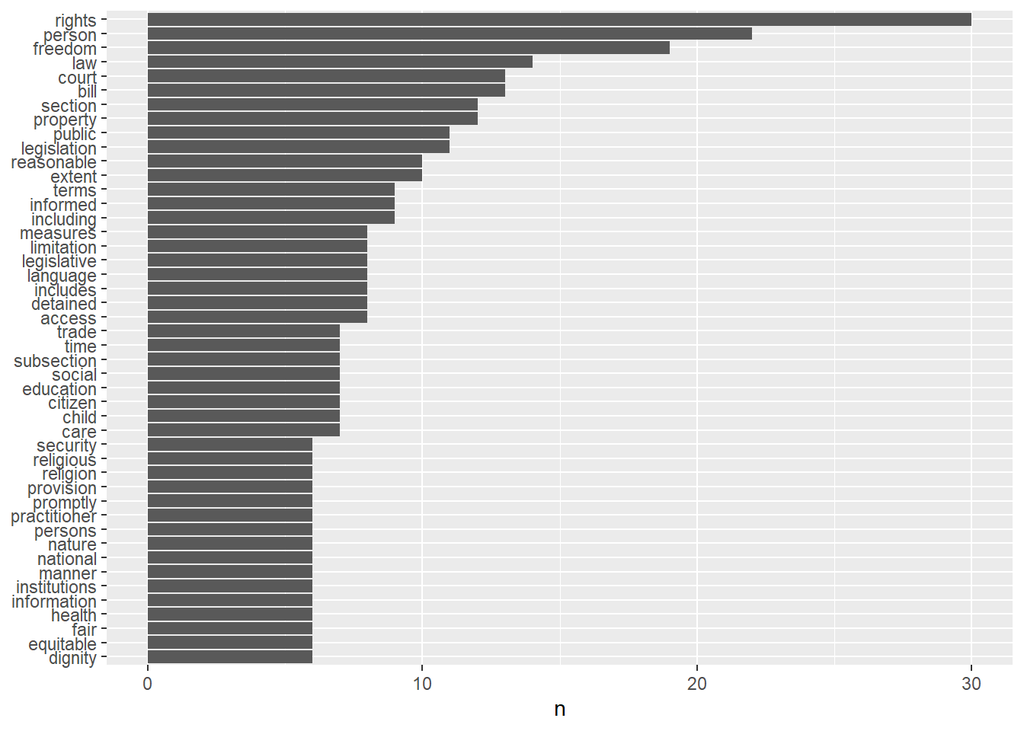

```r
testoSA_df |>
  count(word, sort = TRUE) |>
  filter(n > 5) |>
  mutate(word = reorder(word, n)) |>


  ggplot(aes(n, word)) +
  geom_col() +
  labs(y = NULL)
```

Compared to the previous two texts, I would like to emphasize that this text refers to the rights and principles of the country. The words that are repeated the most are right the person and freedom, even before law. The South African constitution has completely different words from Spain and Italy, which were more similar. It talks about time, child, care, health, nature, fair, equitable. And there is also a word that I consider splendid: dignity.

USA

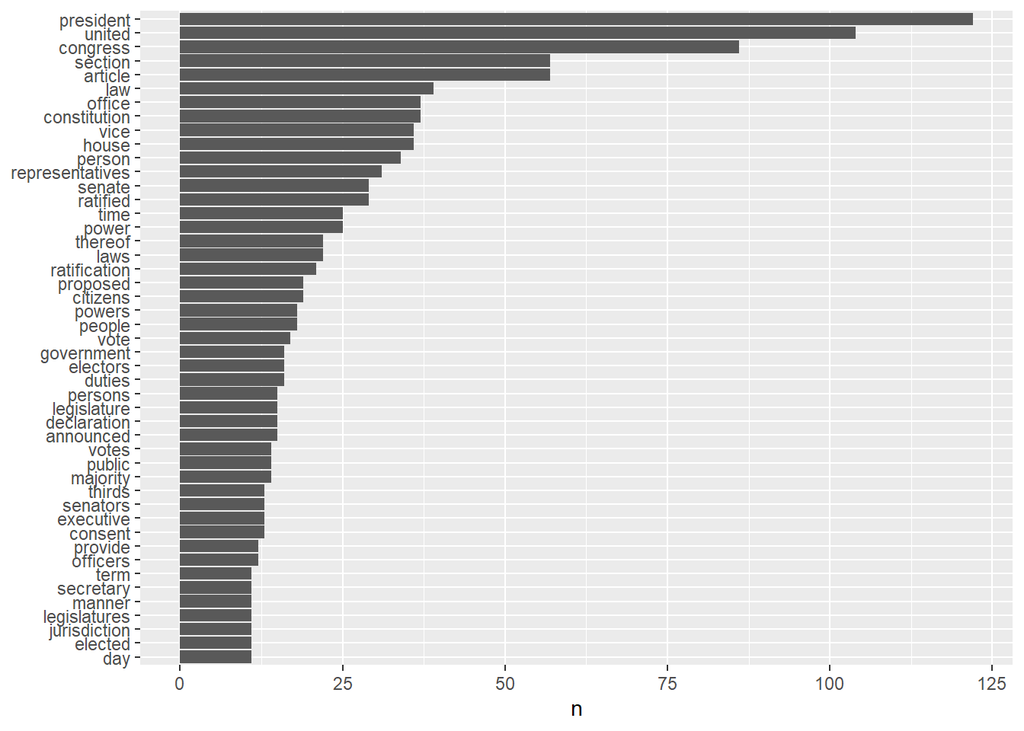

```r
testoUSA_df |>
  count(word, sort = TRUE) |>
  filter(n > 10) |>
  mutate(word = reorder(word, n)) |>


  ggplot(aes(n, word)) +
  geom_col() +
  labs(y = NULL)
```

I am aware that comparing the Declaration of Independence, a text from 1776, with the constitutions of modern states may be considered anachronistic. Despite the addition of 12 amendments and other articles in 1992, it is questionable to compare this text with more recent ones. However, I was very curious and my theory was confirmed: I was certain that the word “president” would be the most repeated.

Last, I left one of the most beautiful legal texts I have ever read: Charter of Fundamental Rights of the European Union. It is a text from 2007, very recent, I included it because we could consider it representative of future trends and hopes.

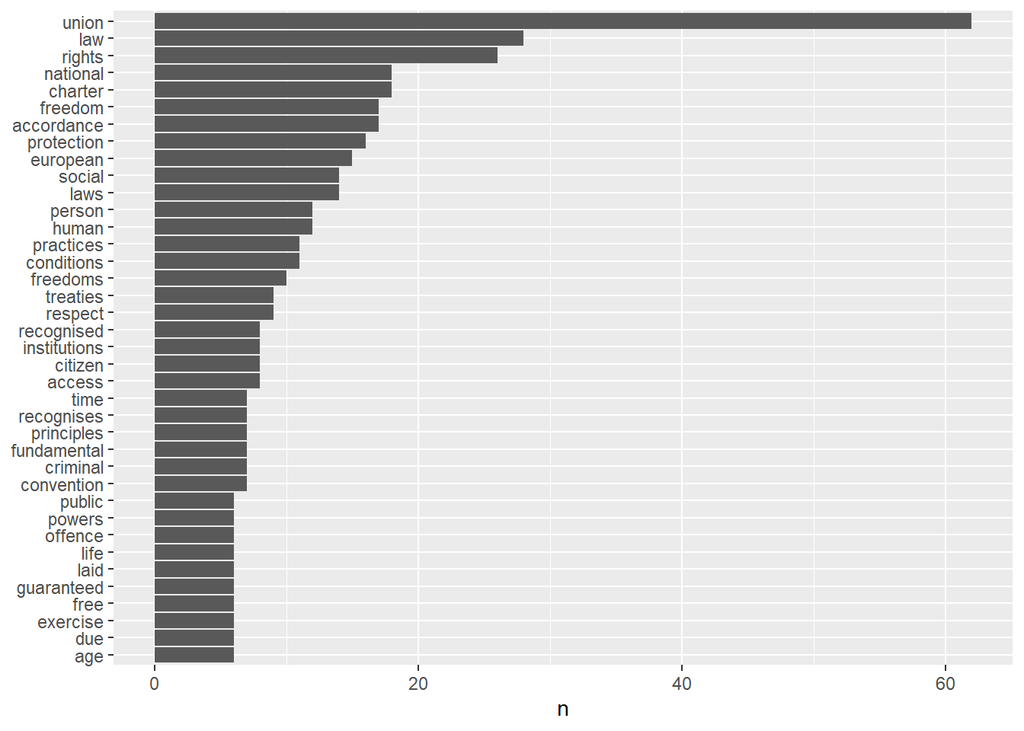

```r
testoue_df |>
  count(word, sort = TRUE) |>
  filter(n > 5) |>
  mutate(word = reorder(word, n)) |>
  ggplot(aes(n, word)) +
  geom_col() +
  labs(y = NULL)
```

Obviously Union is the most repeated word, again there are very interesting words here: human, person, life,free,protection, access. No reference to unipersonal powers like the president. I expected perhaps some reference to labor and peace which are present in the Text, but not as much as I supposed.

## Sentiment analysis

Let’s try to see if there is any positive or negative path in this law texts.

Italy

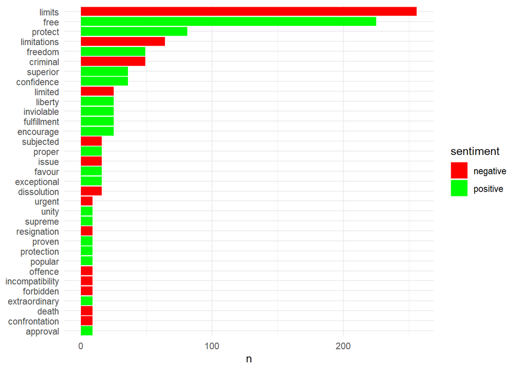

```r
library(textdata)
library(dplyr)
library(ggplot2)

merged_df <- testoit_df %>%
  left_join(get_sentiments("bing"), by = c("word" = "word")) %>%
  filter(!is.na(sentiment))

top_words <- merged_df %>%
  count(word, sort = TRUE) %>%
  slice_max(n, n = 25)

top_words <- top_words %>%
  mutate(word = reorder(word, n))
top_words <- merge(top_words, merged_df, by = "word")


# Create the graph!
ggplot(top_words, aes(x = n, y = word, fill = sentiment)) +
  geom_col() +
  scale_fill_manual(values = c("positive" = "green", "negative" = "red")) +
  labs(y = NULL) +
  theme_minimal()
```

There are many words that are considered neutral in the text, but overall I would say that it is the positive sentiment that prevails.

Spain

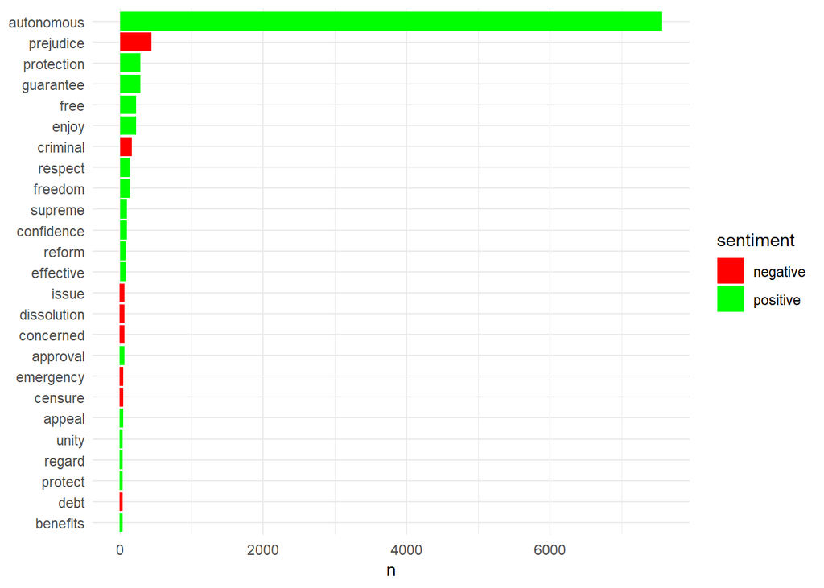

```r
merged_df <- testoes_df %>%
  left_join(get_sentiments("bing"), by = c("word" = "word")) %>%
  filter(!is.na(sentiment))

top_words <- merged_df %>%
  count(word, sort = TRUE) %>%
  slice_max(n, n = 25)

top_words <- top_words %>%
  mutate(word = reorder(word, n))
top_words <- merge(top_words, merged_df, by = "word")


ggplot(top_words, aes(x = n, y = word, fill = sentiment)) +
  geom_col() +
  scale_fill_manual(values = c("positive" = "green", "negative" = "red")) +
  labs(y = NULL) +
  theme_minimal()
```

Even in this case, i think, it’s the positive sentiment to prevail UE

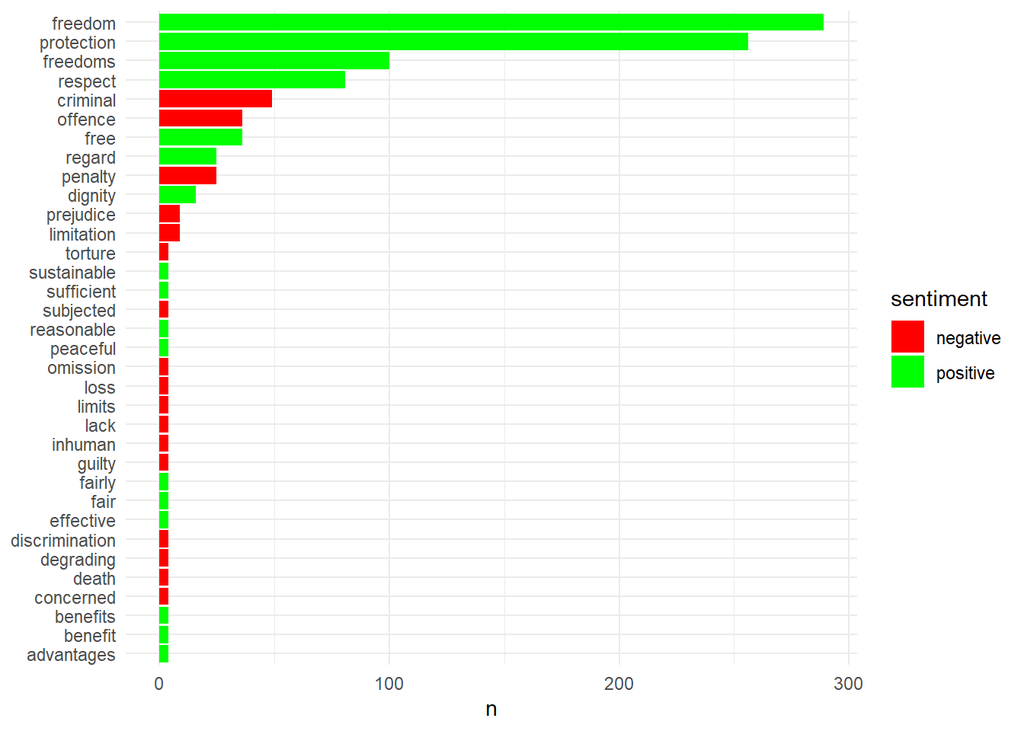

```r
#i used bing because it was the most clear and the results were consistent
merged_df <- testoue_df %>%
  left_join(get_sentiments("bing"), by = c("word" = "word")) %>%
  filter(!is.na(sentiment))
# for the graph i only consider the top 25
top_words <- merged_df %>%
  count(word, sort = TRUE) %>%
  slice_max(n, n = 25)

top_words <- top_words %>%
  mutate(word = reorder(word, n))
top_words <- merge(top_words, merged_df, by = "word")


ggplot(top_words, aes(x = n, y = word, fill = sentiment)) +
  geom_col() +
  scale_fill_manual(values = c("positive" = "green", "negative" = "red")) +
  labs(y = NULL) +
  theme_minimal()
```

the language in this legal text seems to me to be completely distinct; it is more intense than in a normal legal text.

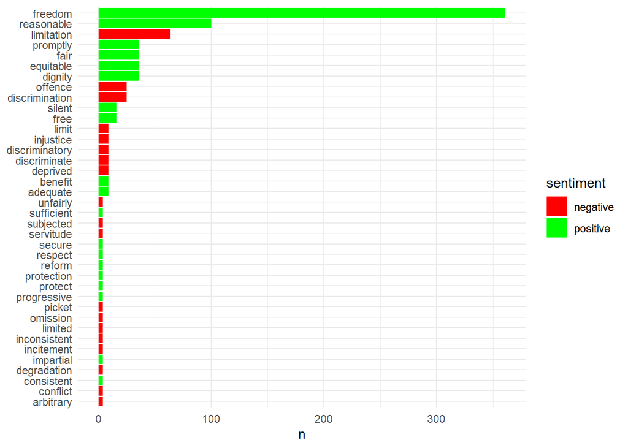

```r
merged_df <- testoSA_df %>%
  left_join(get_sentiments("bing"), by = c("word" = "word")) %>%
  filter(!is.na(sentiment))
top_words <- merged_df %>%
  count(word, sort = TRUE) %>%
  slice_max(n, n = 25)

top_words <- top_words %>%
  mutate(word = reorder(word, n))
top_words <- merge(top_words, merged_df, by = "word")


ggplot(top_words, aes(x = n, y = word, fill = sentiment)) +
  geom_col() +
  scale_fill_manual(values = c("positive" = "green", "negative" = "red")) +
  labs(y = NULL) +
  theme_minimal()
```

We see a certain balance between negative and positive expressions, I also notice a word that had not yet been seen in the selected texts: discriminatory.

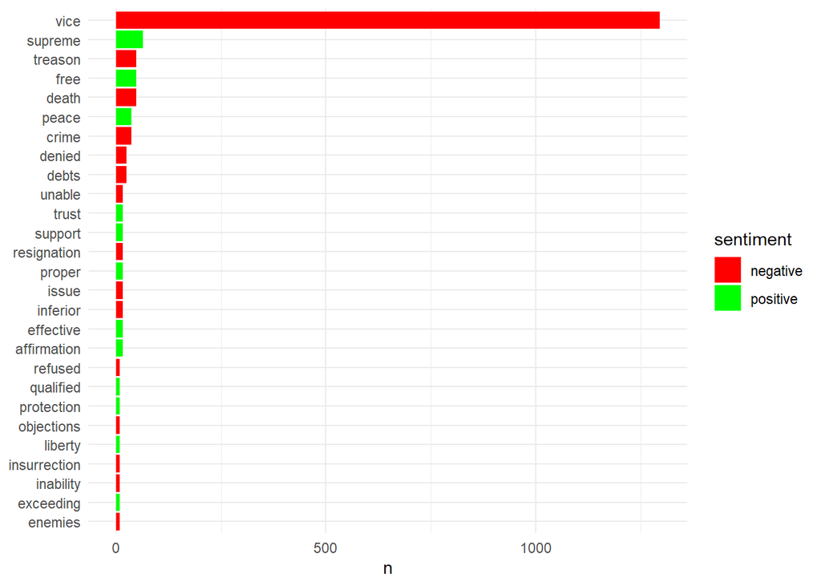

```r
merged_df <- testoUSA_df %>%
  left_join(get_sentiments("bing"), by = c("word" = "word")) %>%
  filter(!is.na(sentiment))

top_words <- merged_df %>%
  count(word, sort = TRUE) %>%
  slice_max(n, n = 25)

top_words <- top_words %>%
  mutate(word = reorder(word, n))
top_words <- merge(top_words, merged_df, by = "word")


ggplot(top_words, aes(x = n, y = word, fill = sentiment)) +
  geom_col() +
  scale_fill_manual(values = c("positive" = "green", "negative" = "red")) +
  labs(y = NULL) +
  theme_minimal()
```

Of all the texts chosen this graph seems to show the greatest presence of negative feelings!

## wordcloud

This is a tool that allows you to graphically and easily summarize previously collected information.

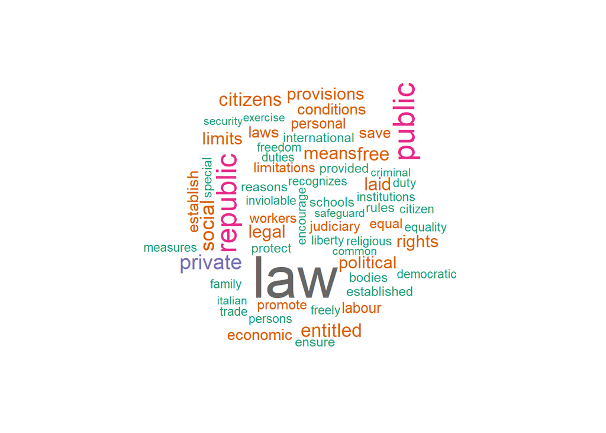

```r
library(wordcloud)
library(RColorBrewer)

testoit_df_principles |>
  count(word) |>
  #we use the wordcloud function
  with(wordcloud(word, n, max.words = 60,colors = brewer.pal(8, 'Dark2') ))
```

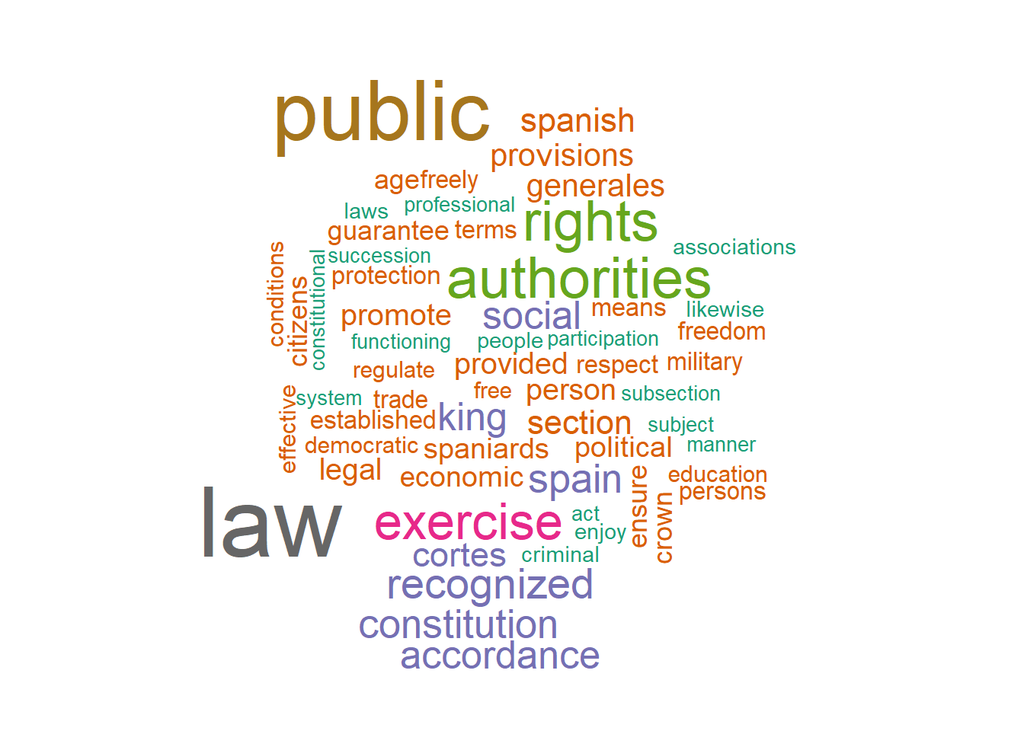

```r
library(wordcloud)
library(RColorBrewer)

testoes_df_principles |>
  count(word) |>
  #we use the wordcloud function
  with(wordcloud(word, n, max.words = 60,colors = brewer.pal(8, 'Dark2') ))
```

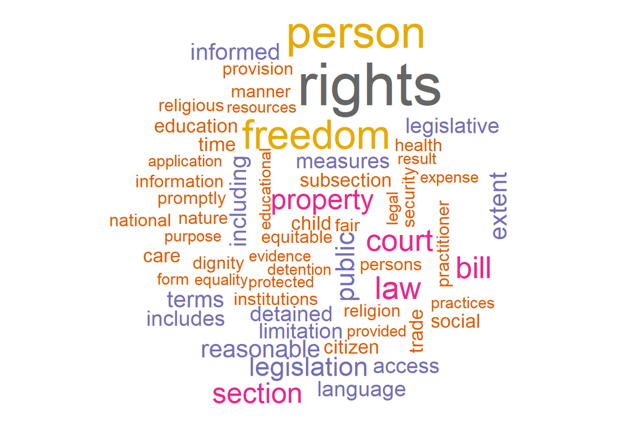

```r
library(wordcloud)
library(RColorBrewer)

testoSA_df |>
  count(word) |>
  #we use the wordcloud function
  with(wordcloud(word, n, max.words = 60,colors = brewer.pal(8, 'Dark2') ))
```

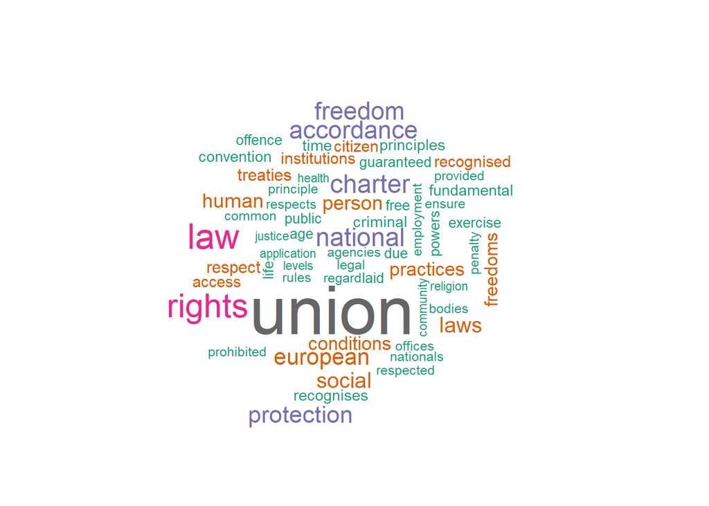

```r
library(wordcloud)
library(RColorBrewer)

testoue_df |>
  count(word) |>
  #we use the wordcloud function
  with(wordcloud(word, n, max.words = 60,colors = brewer.pal(8, 'Dark2') ))
```

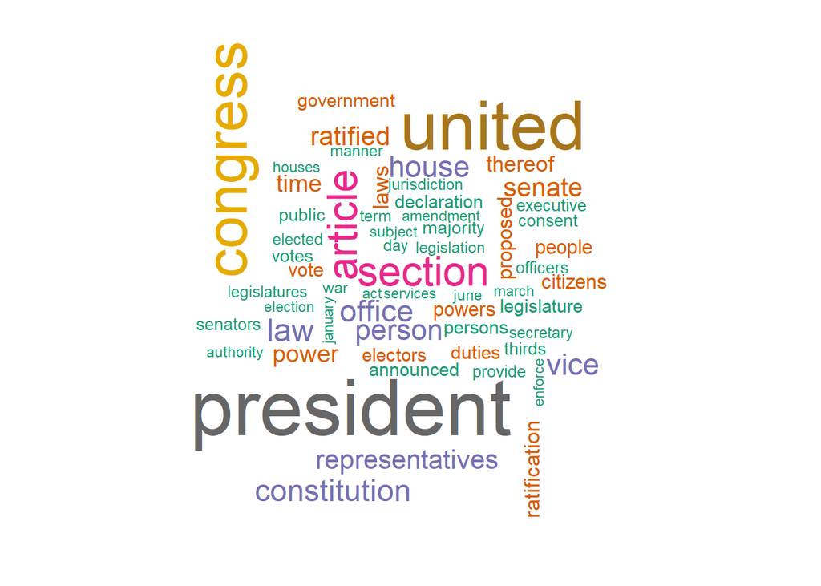

```r
library(wordcloud)
library(RColorBrewer)

testoUSA_df |>
  count(word) |>
  #we use the wordcloud function
  with(wordcloud(word, n, max.words = 60,colors = brewer.pal(8, 'Dark2') ))
```

## Looking for words

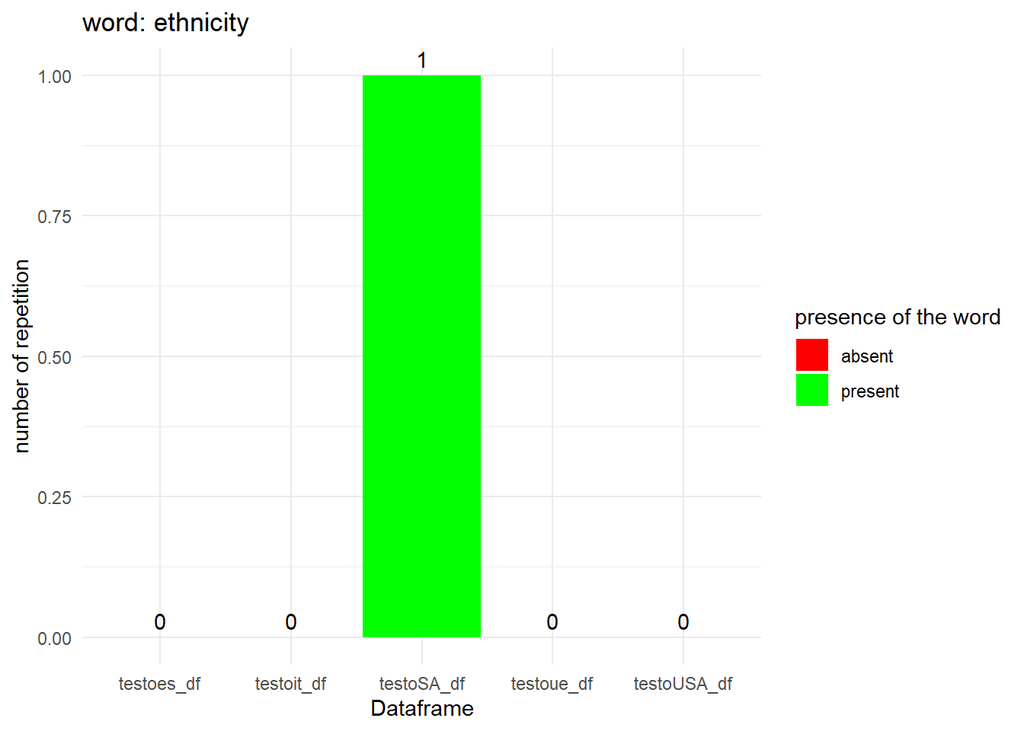

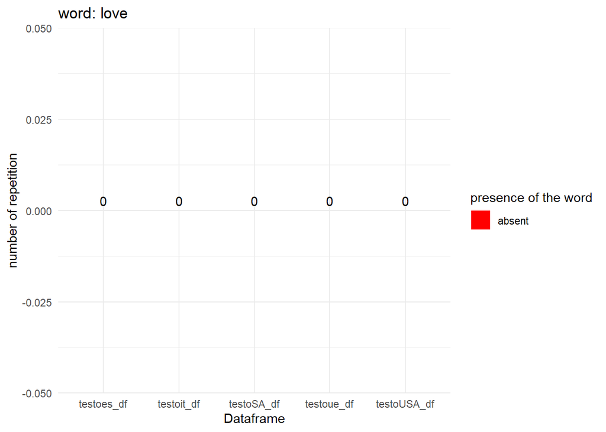

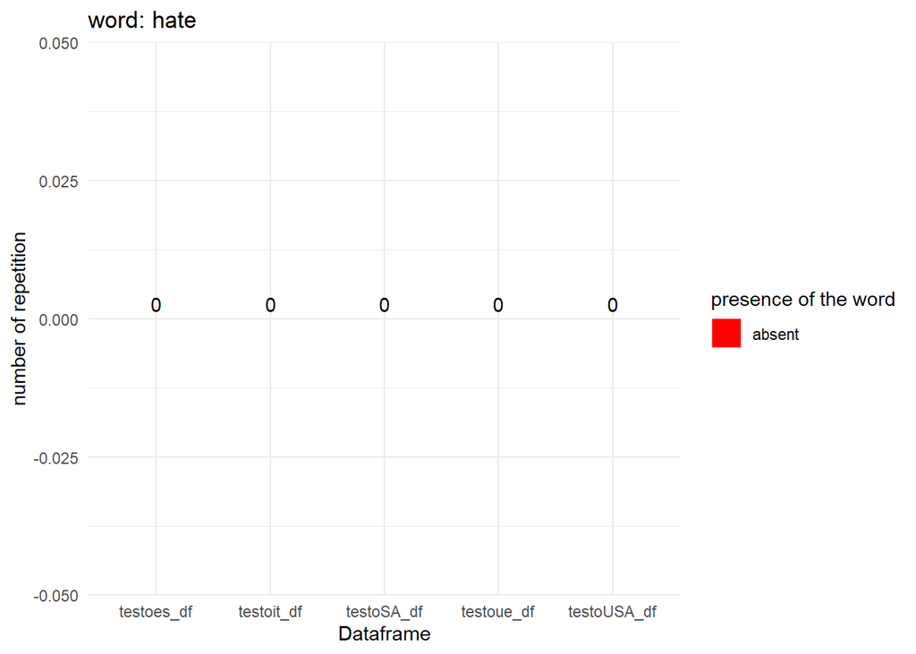

```r
lista_dataframes <- list(testoes_df = testoes_df,
                         testoit_df = testoit_df,
                         testoue_df = testoue_df,
                         testoUSA_df = testoUSA_df,
                         testoSA_df = testoSA_df)

words_searched <- c("ethnicity", "love", "hate")

# new vector
results <- vector(mode = "list", length = length(lista_dataframes))


for (word in words_searched) {
  # looking for the word
  for (i in seq_along(lista_dataframes)) {
    df <- lista_dataframes[[i]]
    present <- word %in% df$word
    repetition<- sum(df$word == word)
    results[[i]] <- list(word = word, present = present, repetition = repetition)
  }

  # the results dataframe
  risultati_df <- data.frame(Dataframe = names(lista_dataframes),
                             word = word,
                             Present = sapply(results, function(x) x$present),
                             Repetition = sapply(results, function(x) x$repetition))

  #the barplot
  print(ggplot(risultati_df, aes(x = Dataframe, y = Repetition, fill = Present)) +
          geom_bar(stat = "identity") +
          scale_fill_manual(values = c("red", "green"), labels = c("absent", "present")) +
          labs(x = "Dataframe", y = "number of repetition", fill = "presence of the word") +
          theme_minimal() +
          geom_text(aes(label = Repetition), vjust = -0.5, color = "black") +
          ggtitle(paste("word:", word)))
}
```

I am romantic so i was curious of knowing if the word “love” was in any of the text, but apparently it is not the love that pushes the law; than i look for another strong word: “hate”, this word was absent too; and then “ethnicity”, that was written only in the Constitution of South Africa. This is explained by the story of that Country, who faced the apartheid since 1948 until 1991.

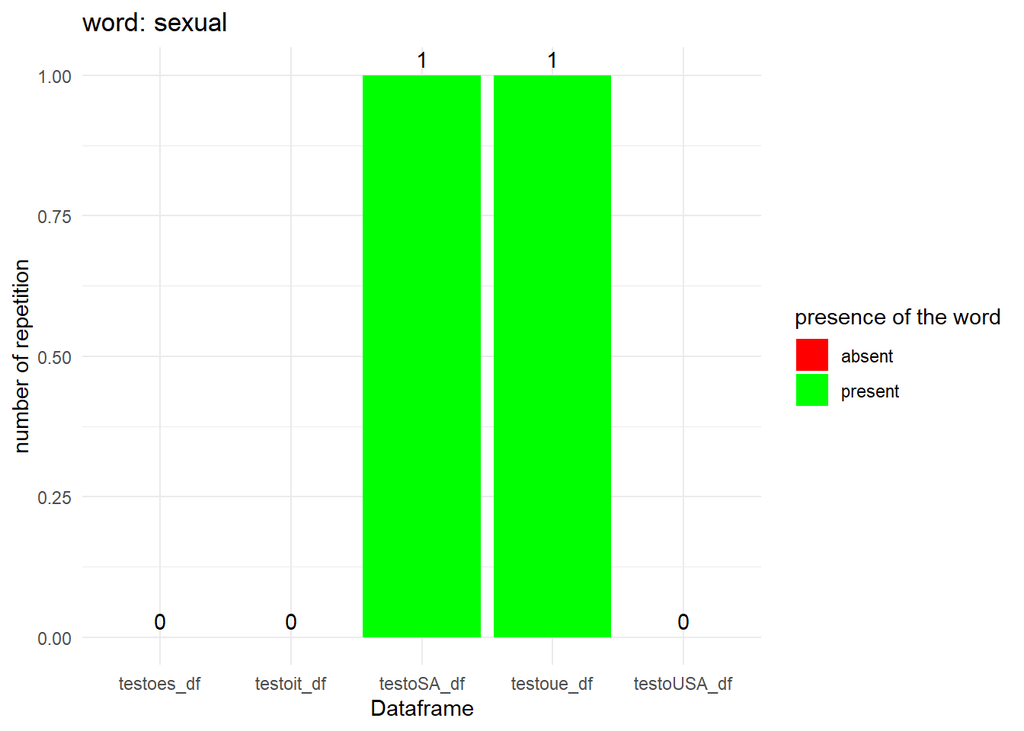

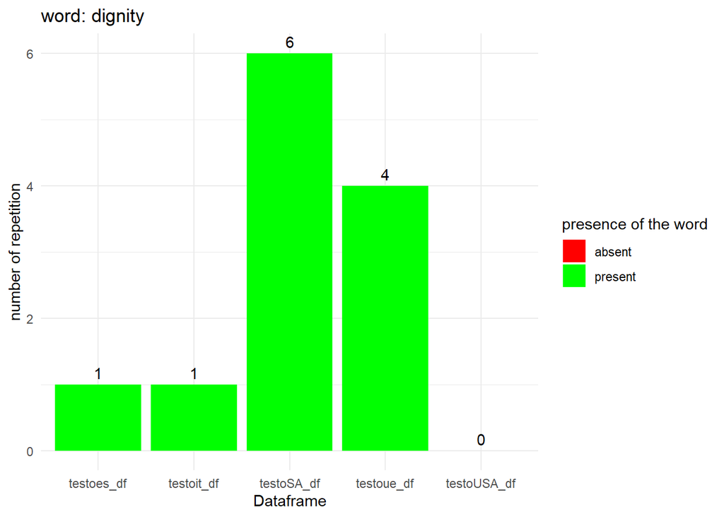

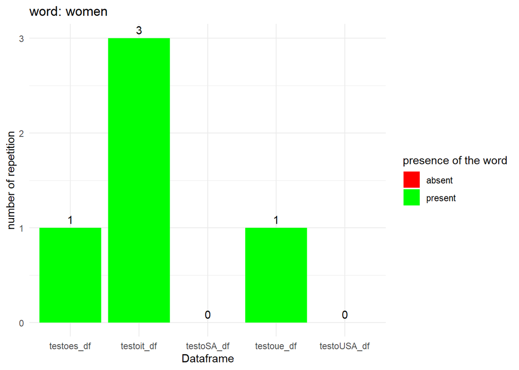

```r
lista_dataframes <- list(testoes_df = testoes_df,
                         testoit_df = testoit_df,
                         testoue_df = testoue_df,
                         testoUSA_df = testoUSA_df,
                         testoSA_df = testoSA_df)

words_searched <- c("sexual", "dignity", "women")

# new vector
results <- vector(mode = "list", length = length(lista_dataframes))


for (word in words_searched) {
  # looking for the word
  for (i in seq_along(lista_dataframes)) {
    df <- lista_dataframes[[i]]
    present <- word %in% df$word
    repetition<- sum(df$word == word)
    results[[i]] <- list(word = word, present = present, repetition = repetition)
  }

  # the results dataframe
  risultati_df <- data.frame(Dataframe = names(lista_dataframes),
                             word = word,
                             Present = sapply(results, function(x) x$present),
                             Repetition = sapply(results, function(x) x$repetition))

  #the barplot
  print(ggplot(risultati_df, aes(x = Dataframe, y = Repetition, fill = Present)) +
          geom_bar(stat = "identity") +
          scale_fill_manual(values = c("red", "green"), labels = c("absent", "present")) +
          labs(x = "Dataframe", y = "number of repetition", fill = "presence of the word") +
          theme_minimal() +
          geom_text(aes(label = Repetition), vjust = -0.5, color = "black") +
          ggtitle(paste("word:", word)))
}
```

“Sexual” was in the European Charter of Fundamental Rights o and in the South Africa constitution. “Dignity” a word that represents and ensures the importance of each one of the citizens was in every text, except in USA. I was not expecting it, but Italy, my country, uses the most the word “women” in its Constitution.

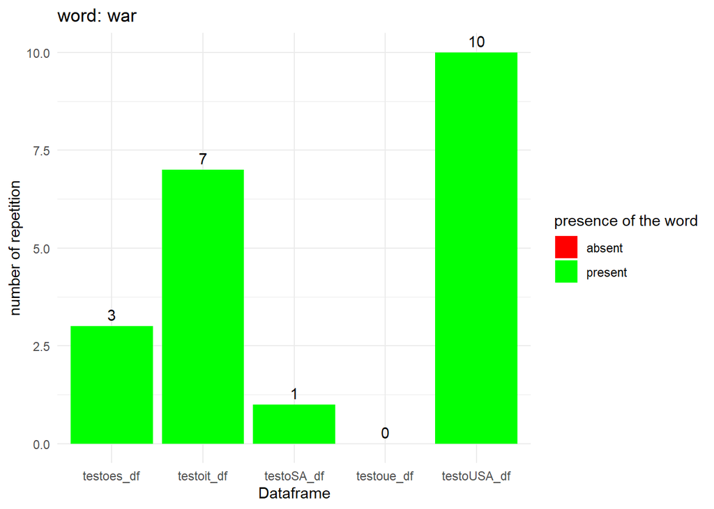

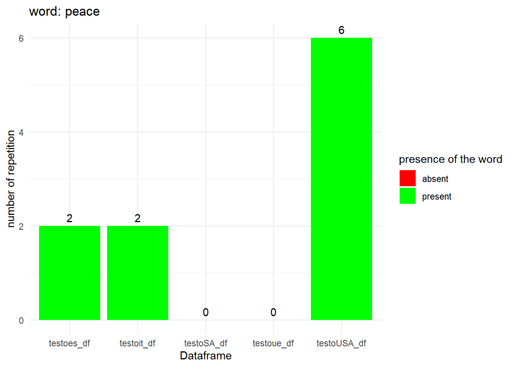

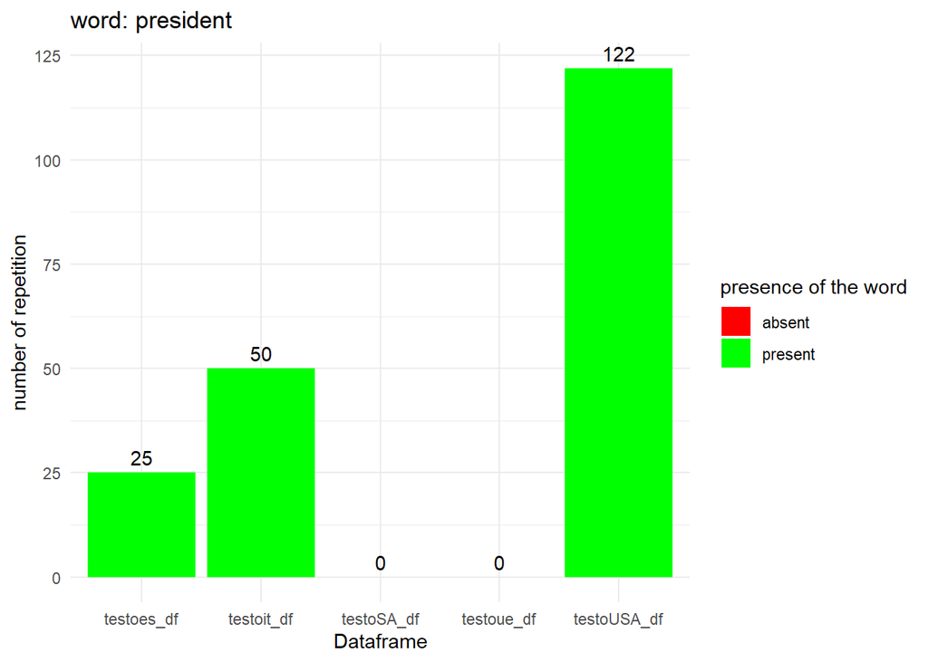

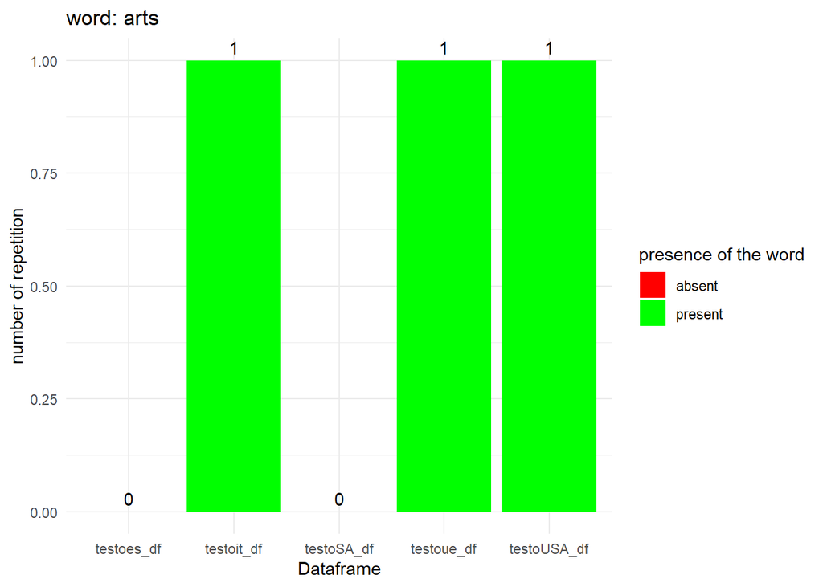

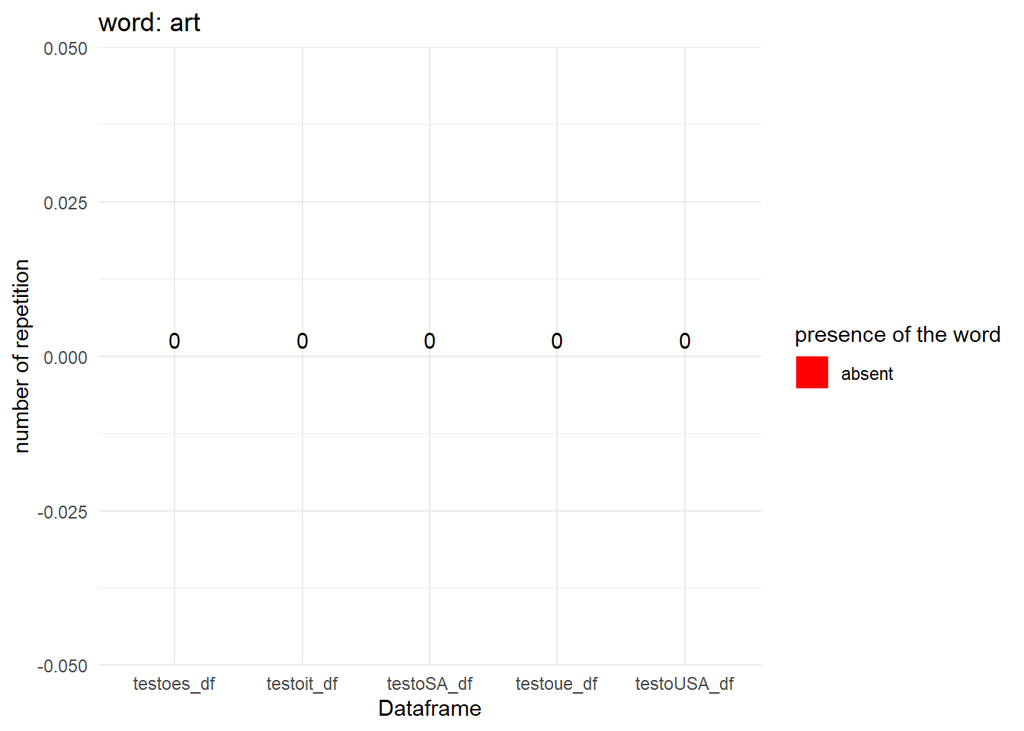

```r
lista_dataframes <- list(testoes_df = testoes_df,
                         testoit_df = testoit_df,
                         testoue_df = testoue_df,
                         testoUSA_df = testoUSA_df,
                         testoSA_df = testoSA_df)

words_searched <- c("war", "peace", "president", "arts", "art")

# new vector
results <- vector(mode = "list", length = length(lista_dataframes))


for (word in words_searched) {
  # looking for the word
  for (i in seq_along(lista_dataframes)) {
    df <- lista_dataframes[[i]]
    present <- word %in% df$word
    repetition<- sum(df$word == word)
    results[[i]] <- list(word = word, present = present, repetition = repetition)
  }

  # the results dataframe
  risultati_df <- data.frame(Dataframe = names(lista_dataframes),
                             word = word,
                             Present = sapply(results, function(x) x$present),
                             Repetition = sapply(results, function(x) x$repetition))

  #the barplot
  print(ggplot(risultati_df, aes(x = Dataframe, y = Repetition, fill = Present)) +
          geom_bar(stat = "identity") +
          scale_fill_manual(values = c("red", "green"), labels = c("absent", "present")) +
          labs(x = "Dataframe", y = "number of repetition", fill = "presence of the word") +
          theme_minimal() +
          geom_text(aes(label = Repetition), vjust = -0.5, color = "black") +
          ggtitle(paste("word:", word)))
}
```

Only the EU Text doesn’t use the word “war”, but seems incredible that in the USA declaration of independence it is repeated ten times.The word “peace” is used less times than the word “war”, maybe it was considered less impactful. THe word “president” surprised me a lot, in the Text of USA it is repeated 122 times, this make sense if we think how much importance and relevance and power the president us there. Then i looked for the “art”, i was wishing that my country, who owes a lot to its art, had given some credit to it in its Constitution, and they did it! as well as the European Union and in Usa’s declaration too. ## N-grams An n-gram is a sequence of n adjacent symbols in particular order. In this case I will try to find a path in the way the words are paired.

```r
it_bigrams <- testoit_df_principles %>%
  mutate(bigram = paste(word, lag(word), sep = " ")) %>%
  filter(!is.na(bigram))
it_bigrams <- it_bigrams %>%
  filter(!grepl("NA", bigram))

head(it_bigrams)
```

```
## # A tibble: 6 × 3
##    line word        bigram
##   <int> <chr>       <chr>
## 1     5 democratic  democratic italy
## 2     5 republic    republic democratic
## 3     5 founded     founded republic
## 4     5 labour      labour founded
## 5     6 sovereignty sovereignty labour
## 6     6 belongs     belongs sovereignty
```

```r
it_bigrams %>%
  count(bigram, sort = TRUE)
```

```
## # A tibble: 1,248 × 2
##    bigram                  n
##    <chr>               <int>
##  1 law laid                8
##  2 bodies public           5
##  3 establish law           4
##  4 laid limits             4
##  5 law established         4
##  6 private public          4
##  7 recognizes republic     4
##  8 social economic         4
##  9 unions trade            4
## 10 economic private        3
## # ℹ 1,238 more rows
```

Since it is a legal text there is an emphasis on the force of law that enhances this text and makes it coercive; there are also two interesting correlations: public-private and social-economic. Union- trade is also mentioned; after the dictatorship and World War II, Italy was trying to recover its trade relations after years of autarky.

```r
es_bigrams <- testoes_df_principles %>%
  mutate(bigram = paste(word, lag(word), sep = " ")) %>%
  filter(!is.na(bigram))

#deleting Na's
es_bigrams <- es_bigrams %>%
  filter(!grepl("NA", bigram))


es_bigrams %>%
  count(bigram, sort = TRUE)
```

```
## # A tibble: 2,077 × 2
##    bigram                    n
##    <chr>                 <int>
##  1 authorities public       29
##  2 generales cortes         14
##  3 promote authorities       8
##  4 guarantee authorities     6
##  5 recognized rights         6
##  6 regulate law              6
##  7 rights exercise           6
##  8 act organic               5
##  9 law accordance            5
## 10 law established           5
## # ℹ 2,067 more rows
```

Again absolute prevalence of words associated with power and legitimacy of acts, probably as a result of the dictatorship they were trying to empower institutions.

South Africa

```r
#separating columns and then pasting to create the bigram
SA_bigrams <- testoSA_df %>%
  mutate(bigram = paste(word, lag(word), sep = " ")) %>%
  filter(!is.na(bigram))


SA_bigrams <- SA_bigrams %>%
  filter(!grepl("NA", bigram))


head(SA_bigrams)
```

```
## # A tibble: 6 × 3
##    line word        bigram
##   <int> <chr>       <chr>
## 1     7 bill        bill rights
## 2     7 rights      rights bill
## 3     7 cornerstone cornerstone rights
## 4     7 democracy   democracy cornerstone
## 5     7 south       south democracy
## 6     7 africa      africa south
```

```r
SA_bigrams %>%
  count(bigram, sort = TRUE)
```

```
## # A tibble: 1,136 × 2
##    bigram                    n
##    <chr>                 <int>
##  1 rights bill              11
##  2 measures legislative      6
##  3 promptly informed         6
##  4 bill rights               5
##  5 legislation national      5
##  6 practitioner legal        5
##  7 action administrative     4
##  8 bill provision            4
##  9 care health               4
## 10 dignity human             4
## # ℹ 1,126 more rows
```

Very different from what was observed for Italy and Spain, here the society of citizens, of human beings, stands out: health-care, dignity-human, rights-bill.

European Union

```r
ue_bigrams <- testoue_df %>%
  mutate(bigram = paste(word, lag(word), sep = " ")) %>%
  filter(!is.na(bigram))


ue_bigrams <- ue_bigrams %>%
  filter(!grepl("NA", bigram))

head(ue_bigrams)
```

```
## # A tibble: 6 × 3
##    line word       bigram
##   <int> <chr>      <chr>
## 1     9 parliament parliament european
## 2     9 council    council parliament
## 3     9 commission commission council
## 4     9 solemnly   solemnly commission
## 5     9 proclaim   proclaim solemnly
## 6     9 text       text proclaim
```

```r
ue_bigrams %>%
  count(bigram, sort = TRUE)
```

```
## # A tibble: 1,158 × 2
##    bigram                  n
##    <chr>               <int>
##  1 laws national          13
##  2 law union              12
##  3 practices laws         10
##  4 union citizen           8
##  5 national law            7
##  6 freedoms rights         6
##  7 recognises union        6
##  8 union european          6
##  9 agencies offices        5
## 10 bodies institutions     5
## # ℹ 1,148 more rows
```

Here reference is made to the role of European institutions and the laws of member countries, clarifying the coexistence of these two aspects within the Union.

USA

```r
USA_bigrams <- testoUSA_df %>%
  mutate(bigram = paste(word, lag(word), sep = " ")) %>%
  filter(!is.na(bigram))

USA_bigrams <- USA_bigrams %>%
  filter(!grepl("NA", bigram))


USA_bigrams %>%
  count(bigram, sort = TRUE)
```

```
## # A tibble: 2,924 × 2
##    bigram                     n
##    <chr>                  <int>
##  1 president vice            36
##  2 congress proposed         19
##  3 representatives house     18
##  4 announced ratification    13
##  5 vice president            12
##  6 congress section          11
##  7 power congress            11
##  8 president office          10
##  9 secretary announced       10
## 10 duties powers              9
## # ℹ 2,914 more rows
```

Absolute predominance of the role of the president, the powers of the state, and the institutions that represent it.

## bigram graph

Graphs to represent the relationship between words in texts and their “laws of attraction.”

I created a function to make automatic the process.

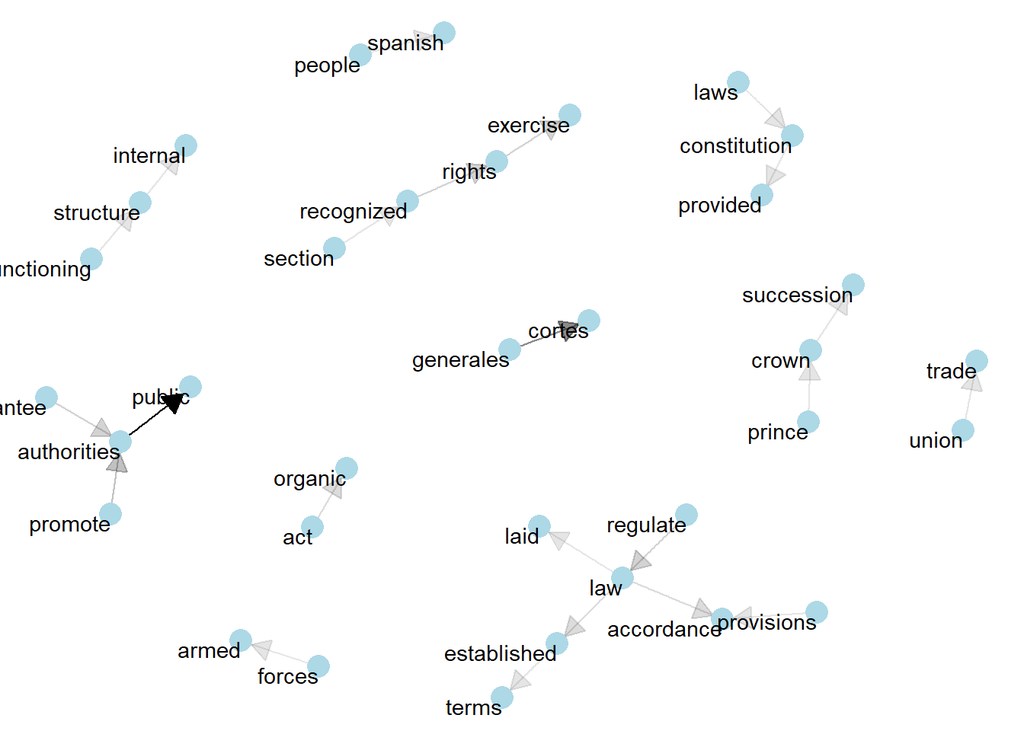

```r
library(tidyr)
library(dplyr)
library(ggraph)  #package for bigram network's relationship
library(grid)

create_bigram_graph <- function(df, min_occurrences = 5, num_top_words = 10) {
  # Separate the bigram column into two columns word1 and word2
  df <- df %>%
    separate(bigram, into = c("word1", "word2"), sep = " ")

  # Count the occurrences of bigrams
  bigram_counts <- df %>%
    count(word1, word2, sort = TRUE)

  # Filter bigrams with a number of occurrences greater than the minimum value
  bigram_for_graph <- bigram_counts %>%
    filter(n > min_occurrences)

  # Use ggraph to create the graph
  set.seed(2020)
  a <- grid::arrow(type = "closed", length = unit(.15, "inches"))
  g <- ggraph(bigram_for_graph, layout = "fr") +
    geom_edge_link(aes(edge_alpha = n), show.legend = FALSE,
                   arrow = a, end_cap = circle(.07, 'inches')) +
    geom_node_point(color = "lightblue", size = 5) +
    geom_node_text(aes(label = name), vjust = 1, hjust = 1) +
    theme_void()

  return(g)
}

# Usage of the function to create the graph
bigram_graph <- create_bigram_graph(es_bigrams, min_occurrences = 3)
bigram_graph
```

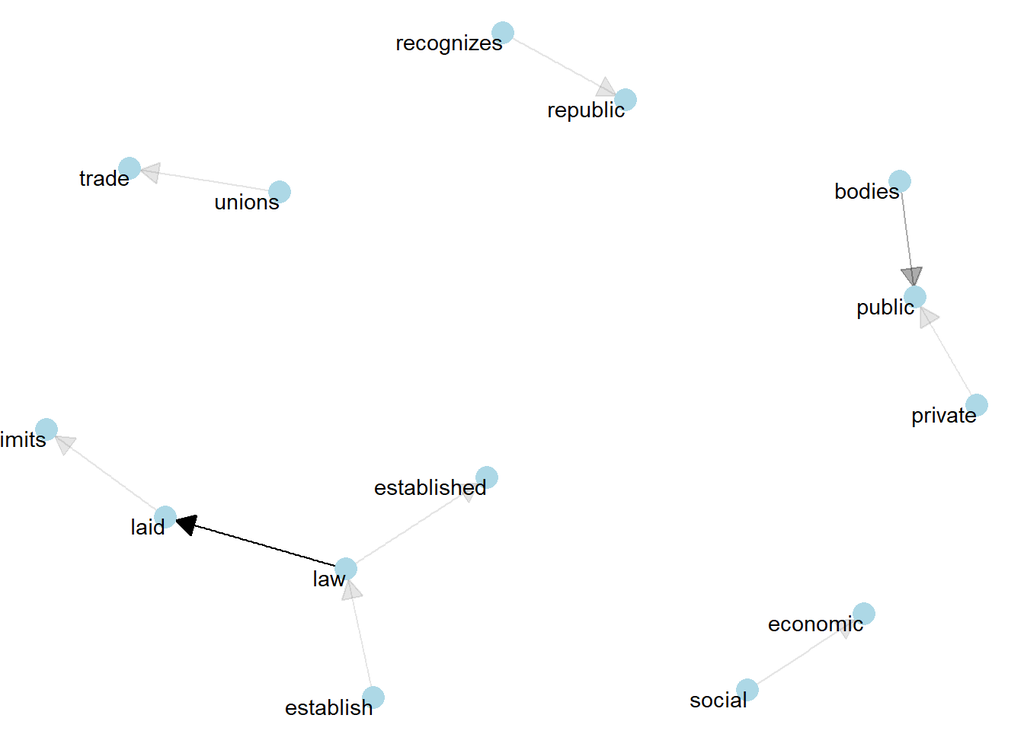

```r
bigram_graph <- create_bigram_graph(it_bigrams, min_occurrences = 3)
bigram_graph
```

South Africa

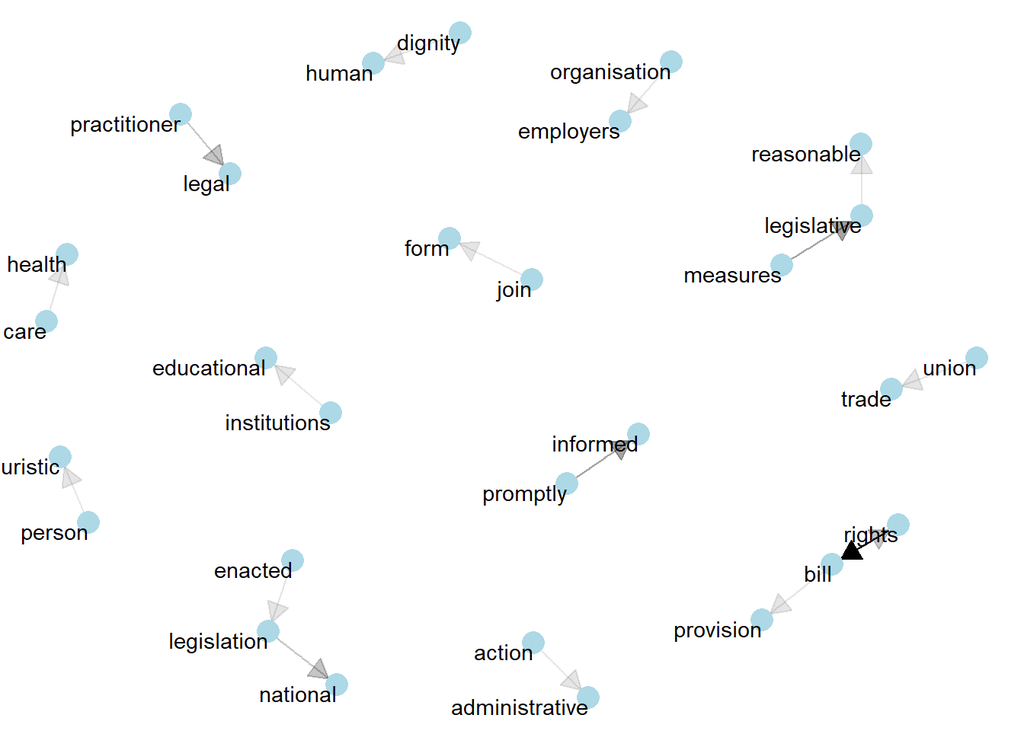

```r
bigram_graphSA <- create_bigram_graph(SA_bigrams, min_occurrences = 3)
bigram_graphSA
```

European Union

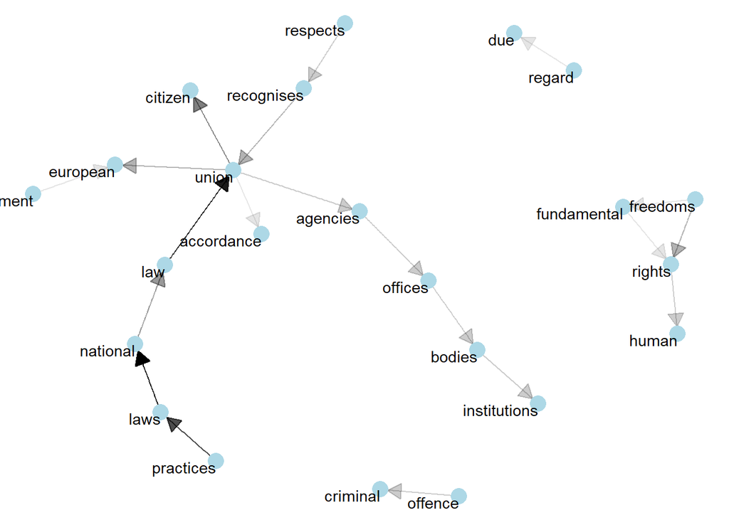

```r
bigram_graph_ue <- create_bigram_graph(ue_bigrams, min_occurrences = 3)
bigram_graph_ue
```

USA

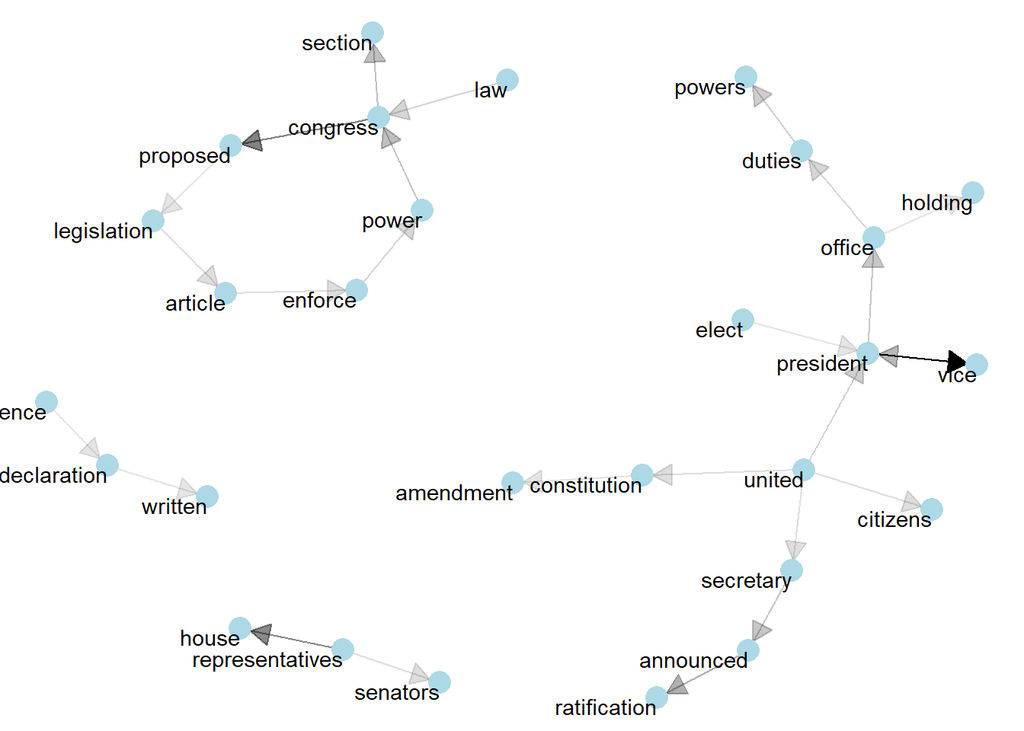

```r
bigram_graph_USA <- create_bigram_graph(USA_bigrams, min_occurrences = 5)
bigram_graph_USA
```